# Automated workflow

Let’s use [`drake`](https://github.com/ropensci/drake) to train and compare multiple models in a unified automated workflow.

## Packages

First, we load our packages into a fresh R session.

```r
library(drake)
library(keras)
library(tidyverse)
library(rsample)
library(recipes)
library(yardstick)
```

## Functions

[`drake`](https://github.com/ropensci/drake) is R-focused and function-oriented. We create functions to [preprocess the data](https://github.com/tidymodels/recipes),

```r
prepare_recipe <- function(data) {
  data %>%
    training() %>%
    recipe(Churn ~ .) %>%
    step_rm(customerID) %>%
    step_naomit(all_outcomes(), all_predictors()) %>%
    step_discretize(tenure, options = list(cuts = 6)) %>%
    step_log(TotalCharges) %>%
    step_mutate(Churn = ifelse(Churn == "Yes", 1, 0)) %>%
    step_dummy(all_nominal(), -all_outcomes()) %>%
    step_center(all_predictors(), -all_outcomes()) %>%
    step_scale(all_predictors(), -all_outcomes()) %>%
    prep()
}
```

define a [`keras`](https://github.com/rstudio/keras) model, exposing arguments to set the dimensionality and activation functions of the layers,

```r
define_model <- function(rec, units1, units2, act1, act2, act3) {
  input_shape <- ncol(
    juice(rec, all_predictors(), composition = "matrix")
  )
  keras_model_sequential() %>%
    layer_dense(
      units = units1,
      kernel_initializer = "uniform",
      activation = act1,
      input_shape = input_shape
    ) %>%
    layer_dropout(rate = 0.1) %>%
    layer_dense(
      units = units2,
      kernel_initializer = "uniform",
      activation = act2
    ) %>%
    layer_dropout(rate = 0.1) %>%
    layer_dense(
      units = 1,
      kernel_initializer = "uniform",
      activation = act3
    )
}
```

train a model,

```r
train_model <- function(
  data,
  rec,
  units1 = 16,
  units2 = 16,
  act1 = "relu",
  act2 = "relu",
  act3 = "sigmoid"
) {
  model <- define_model(
    rec = rec,
    units1 = units1,
    units2 = units2,
    act1 = act1,
    act2 = act2,
    act3 = act3
  )
  compile(
    model,
    optimizer = "adam",
    loss = "binary_crossentropy",
    metrics = c("accuracy")
  )
  x_train_tbl <- juice(
    rec,
    all_predictors(),
    composition = "matrix"
  )
  y_train_vec <- juice(rec, all_outcomes()) %>%
    pull()
  fit(
    object = model,
    x = x_train_tbl,
    y = y_train_vec,
    batch_size = 32,
    epochs = 32,
    validation_split = 0.3,
    verbose = 0
  )
  model
}
```

compare predictions against reality,

```r
confusion_matrix <- function(data, rec, model) {
  testing_data <- bake(rec, testing(data))
  x_test_tbl <- testing_data %>%
    select(-Churn) %>%
    as.matrix()
  y_test_vec <- testing_data %>%
    select(Churn) %>%
    pull()
  yhat_keras_class_vec <- model %>%
    predict_classes(x_test_tbl) %>%
    as.factor() %>%
    fct_recode(yes = "1", no = "0")
  yhat_keras_prob_vec <-
    model %>%
    predict_proba(x_test_tbl) %>%
    as.vector()
  test_truth <- y_test_vec %>%
    as.factor() %>%
    fct_recode(yes = "1", no = "0")
  estimates_keras_tbl <- tibble(
    truth = test_truth,
    estimate = yhat_keras_class_vec,
    class_prob = yhat_keras_prob_vec
  )
  estimates_keras_tbl %>%
    conf_mat(truth, estimate)
}
```

and compare the performance of multiple models.

```r
compare_models <- function(...) {
  name <- match.call()[-1] %>%
    as.character()
  df <- map_df(list(...), summary) %>%
    filter(.metric %in% c("accuracy", "sens", "spec")) %>%
    mutate(name = rep(name, each = n() / length(name))) %>%
    rename(metric = .metric, estimate = .estimate)
  ggplot(df) +
    geom_line(aes(x = metric, y = estimate, color = name, group = name)) +
    theme_gray(24)
}
```

## Plan

Next, we define our workflow in a [`drake` plan](https://ropenscilabs.github.io/drake-manual/plans.html). We will prepare the data, train different models with different activation functions, and compare the models in terms of performance.

```r
activations <- c("relu", "sigmoid")

plan <- drake_plan(
  data = read_csv(file_in("customer_churn.csv"), col_types = cols()) %>%
    initial_split(prop = 0.3),
  rec = prepare_recipe(data),
  model = target(
    train_model(data, rec, act1 = act),
    format = "keras", # Supported in drake > 7.5.2 to store models properly.
    transform = map(act = !!activations)
  ),
  conf = target(
    confusion_matrix(data, rec, model),
    transform = map(model, .id = act)
  ),
  metrics = target(
    compare_models(conf),
    transform = combine(conf)
  )
)
```

The plan is a data frame with the steps we are going to do.

```r
plan
```

```
# A tibble: 7 x 3
  target      command                                           format
  <chr>       <expr>                                            <chr>
1 data        read_csv(file_in("customer_churn.csv"), col_type… <NA>
2 rec         prepare_recipe(data)                            … <NA>
3 model_relu  train_model(data, rec, act1 = "relu")           … keras
4 model_sigm… train_model(data, rec, act1 = "sigmoid")        … keras
5 conf_relu   confusion_matrix(data, rec, model_relu)         … <NA>
6 conf_sigmo… confusion_matrix(data, rec, model_sigmoid)      … <NA>
7 metrics     compare_models(conf_relu, conf_sigmoid)         … <NA>
```

## Dependency graph

The graph visualizes the dependency relationships among the steps of the workflow.

```r
config <- drake_config(plan)
vis_drake_graph(config)
```

[interactive chart not shown]

## Run the models

Call [`make()`](https://ropensci.github.io/drake/reference/make.html) to actually run the workflow.

```r
make(plan)
```

```
target data
target rec
target model_relu
target model_sigmoid
target conf_relu
target conf_sigmoid
target metrics
```

## Inspect the results

The two models performed about the same.

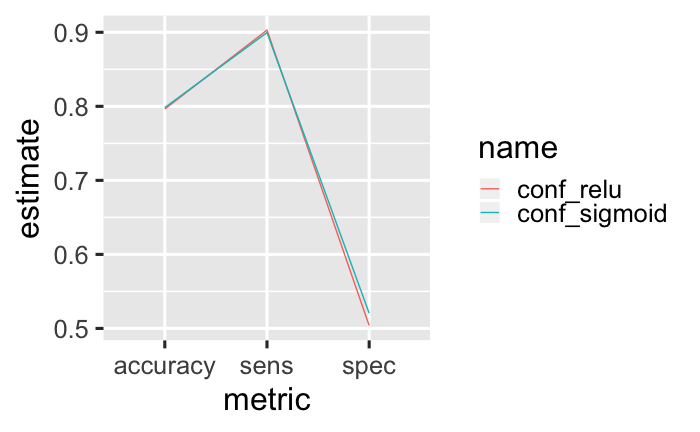

```r
readd(metrics) # see also loadd()
```

## Add models

Let’s try another activation function.

```r
activations <- c("relu", "sigmoid", "softmax")

plan <- drake_plan(
  data = read_csv(file_in("customer_churn.csv"), col_types = cols()) %>%
    initial_split(prop = 0.3),
  rec = prepare_recipe(data),
  model = target(
    train_model(data, rec, act1 = act),
    format = "keras", # Supported in drake > 7.5.2 to store models properly.
    transform = map(act = !!activations)
  ),
  conf = target(
    confusion_matrix(data, rec, model),
    transform = map(model, .id = act)
  ),
  metrics = target(
    compare_models(conf),
    transform = combine(conf)
  )
)
```

```r
config <- drake_config(plan)
vis_drake_graph(config) # see also outdated() and predict_runtime()
```

[interactive chart not shown]

[`make()`](https://ropensci.github.io/drake/reference/make.html) only trains the outdated or missing models and refreshes the post-processing. It skips the targets that are already up to date.

```r
make(plan)
```

```
target model_softmax
target conf_softmax
target metrics
```

## Inspect the results again

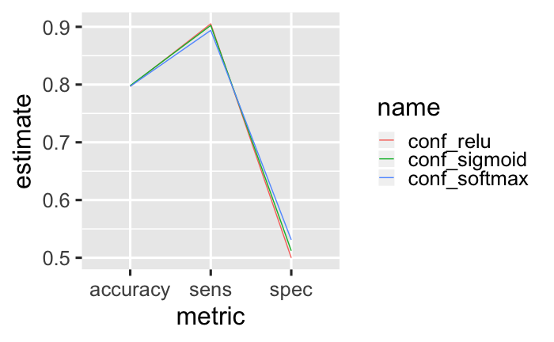

```r
readd(metrics) # see also loadd()
```

## Update your code

If you change upstream functions in your environment, even nested ones, `drake` automatically refits the affected models. Let’s increase dropout in both layers.

```r
define_model <- function(rec, units1, units2, act1, act2, act3) {
  input_shape <- ncol(
    juice(rec, all_predictors(), composition = "matrix")
  )
  keras_model_sequential() %>%
    layer_dense(
      units = units1,
      kernel_initializer = "uniform",
      activation = act1,
      input_shape = input_shape
    ) %>%
    layer_dropout(rate = 0.15) %>% # Changed from 0.1 to 0.15.
    layer_dense(
      units = units2,
      kernel_initializer = "uniform",
      activation = act2
    ) %>%
    layer_dropout(rate = 0.15) %>% # Changed from 0.1 to 0.15.
    layer_dense(
      units = 1,
      kernel_initializer = "uniform",
      activation = act3
    )
}
```

```r
make(plan)
```

```
target model_relu
target model_sigmoid
target model_softmax
target conf_relu
target conf_sigmoid
target conf_softmax
target metrics
```

## History and provenance

`drake` version 7.5.0 and above tracks history and provenance. You can see which models you ran, when you ran them, how long they took, and which settings you tried (i.e. named arguments to function calls in your commands).

```r
history <- drake_history()
history
```

| target | current | built | exists | hash | command | seed | runtime | prop | act1 |
| --- | --- | --- | --- | --- | --- | --- | --- | --- | --- |
| conf_relu | FALSE | 2019-08-08 13:02:22.384139 -0400 GMT | TRUE | 2792ae9935ae28e9 | confusion_matrix(data, rec, model_relu) | 404527372 | 0.694 | NA | NA |
| conf_relu | TRUE | 2019-08-08 13:02:50.730181 -0400 GMT | TRUE | 0b818f5fe1ff0c59 | confusion_matrix(data, rec, model_relu) | 404527372 | 0.566 | NA | NA |
| conf_sigmoid | FALSE | 2019-08-08 13:02:22.779814 -0400 GMT | TRUE | 652f70bb1cce62e6 | confusion_matrix(data, rec, model_sigmoid) | 1927088172 | 0.378 | NA | NA |
| conf_sigmoid | TRUE | 2019-08-08 13:02:51.301637 -0400 GMT | TRUE | 03ee3392b3e26be5 | confusion_matrix(data, rec, model_sigmoid) | 1927088172 | 0.549 | NA | NA |
| conf_softmax | FALSE | 2019-08-08 13:02:30.395701 -0400 GMT | TRUE | caf9e5f2db344715 | confusion_matrix(data, rec, model_softmax) | 1797696873 | 0.459 | NA | NA |
| conf_softmax | TRUE | 2019-08-08 13:02:51.871833 -0400 GMT | TRUE | ba81eb9f574234ab | confusion_matrix(data, rec, model_softmax) | 1797696873 | 0.549 | NA | NA |
| data | TRUE | 2019-08-08 13:02:10.349436 -0400 GMT | TRUE | 134757b39f053546 | read_csv(file_in("customer_churn.csv"), col_types = cols()) %>% \n initial_split(prop = 0.3) | 1286961461 | 0.024 | 0.3 | NA |
| metrics | FALSE | 2019-08-08 13:02:22.831167 -0400 GMT | TRUE | cc66f81772c8d736 | compare_models(conf_relu, conf_sigmoid) | 1205251934 | 0.022 | NA | NA |
| metrics | FALSE | 2019-08-08 13:02:30.482012 -0400 GMT | TRUE | fd7e1147423a5023 | compare_models(conf_relu, conf_sigmoid, conf_softmax) | 1205251934 | 0.053 | NA | NA |
| metrics | TRUE | 2019-08-08 13:02:51.967488 -0400 GMT | TRUE | 4c8e486a960b4c7a | compare_models(conf_relu, conf_sigmoid, conf_softmax) | 1205251934 | 0.056 | NA | NA |

[output cut: 7 more lines]

And as long as you did not run `clean(garbage_collection = TRUE)`, you can get the old data back. Let’s find the oldest run of the relu model.

```r
hash <- history %>%
  filter(act1 == "relu") %>%
  pull(hash) %>%
  head(n = 1)
drake_cache()$get_value(hash)
```

```
Model
______________________________________________________________________
Layer (type)                   Output Shape                Param #
======================================================================
dense_18 (Dense)               (None, 16)                  576
______________________________________________________________________
dropout_12 (Dropout)           (None, 16)                  0
______________________________________________________________________
dense_19 (Dense)               (None, 16)                  272
______________________________________________________________________
dropout_13 (Dropout)           (None, 16)                  0
______________________________________________________________________
dense_20 (Dense)               (None, 1)                   17
======================================================================
Total params: 865
Trainable params: 865
Non-trainable params: 0
______________________________________________________________________
```

## Tips

- To see this workflow [organized as a collection of modular scripts](https://ropenscilabs.github.io/drake-manual/projects.html), see the customer churn examples in [this repository](https://github.com/wlandau/drake-examples). You can download the code with `drake_example("customer-churn")`.
- [`drake`](https://github.com/ropensci/drake) has [built-in distributed computing support](https://ropenscilabs.github.io/drake-manual/hpc.html) that lets you fit multiple models in parallel.